# Experimentos TFM

### Grupos

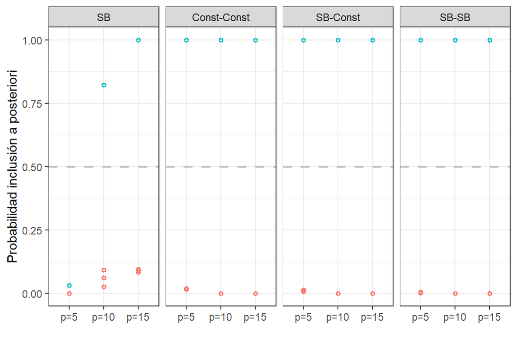

En función del número de variables en cada grupo:

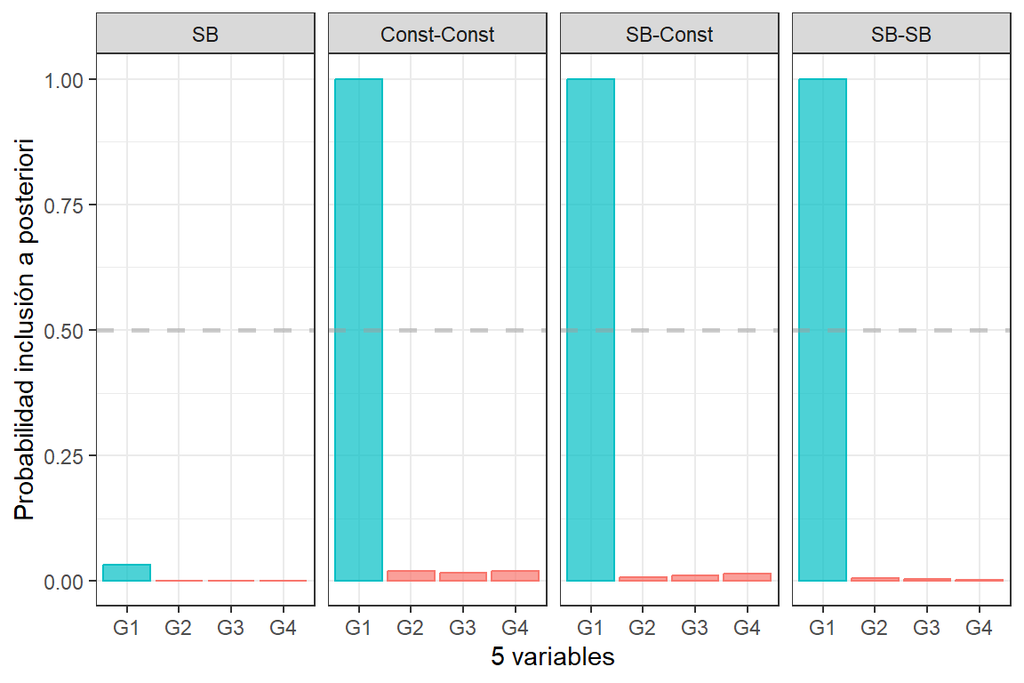

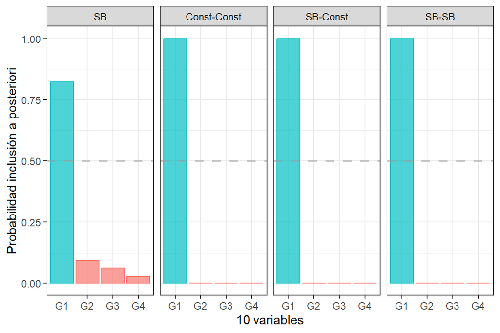

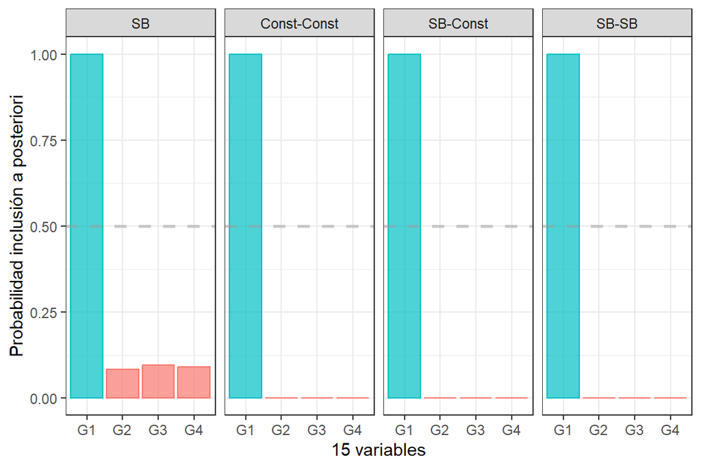

Probabilidad para cada grupo según el número de variables con SB.

|  | G1 | G2 | G3 | G4 |
| --- | --- | --- | --- | --- |
| p=5 | 0.03 | 0.00 | 0.00 | 0.00 |
| p=10 | 0.82 | 0.09 | 0.06 | 0.03 |
| p=15 | 1.00 | 0.08 | 0.10 | 0.09 |

Probabilidad para cada grupo según el número de variables con Const-Const.

|  | G1 | G2 | G3 | G4 |
| --- | --- | --- | --- | --- |
| p=5 | 1 | 0.02 | 0.02 | 0.02 |
| p=10 | 1 | 0.00 | 0.00 | 0.00 |
| p=15 | 1 | 0.00 | 0.00 | 0.00 |

Probabilidad para cada grupo según el número de variables con SB-Const.

|  | G1 | G2 | G3 | G4 |
| --- | --- | --- | --- | --- |
| p=5 | 1 | 0.01 | 0.01 | 0.01 |
| p=10 | 1 | 0.00 | 0.00 | 0.00 |
| p=15 | 1 | 0.00 | 0.00 | 0.00 |

Probabilidad para cada grupo según el número de variables con SB-SB.

|  | G1 | G2 | G3 | G4 |
| --- | --- | --- | --- | --- |
| p=5 | 1 | 0.01 | 0 | 0 |
| p=10 | 1 | 0.00 | 0 | 0 |
| p=15 | 1 | 0.00 | 0 | 0 |

### Variables agrupadas

En general:

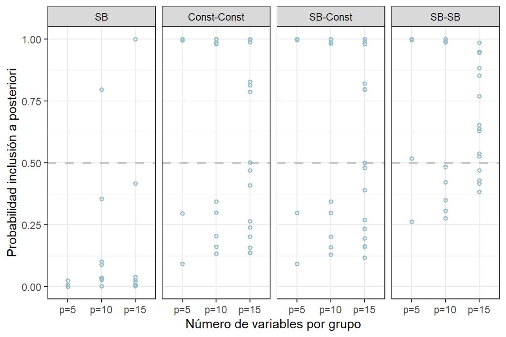

En función del número de variables en cada grupo:

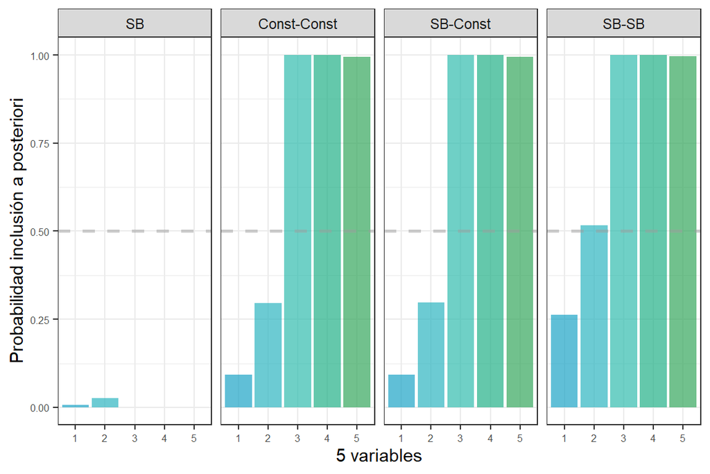

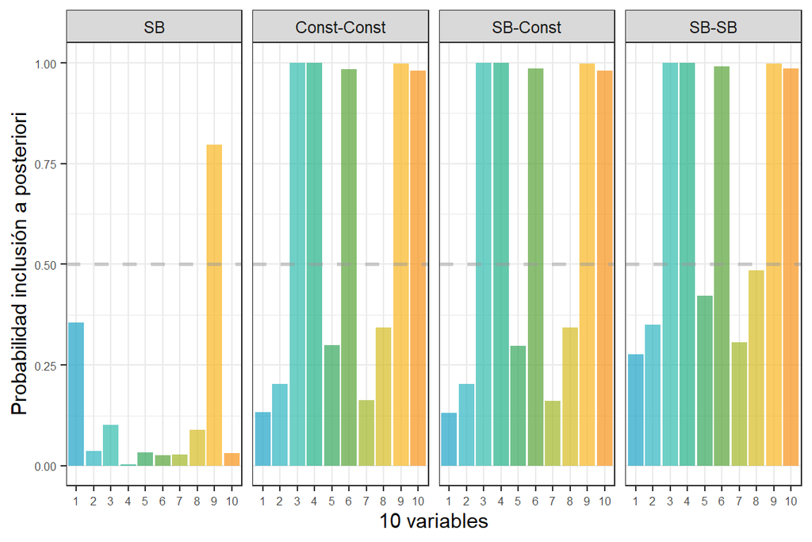

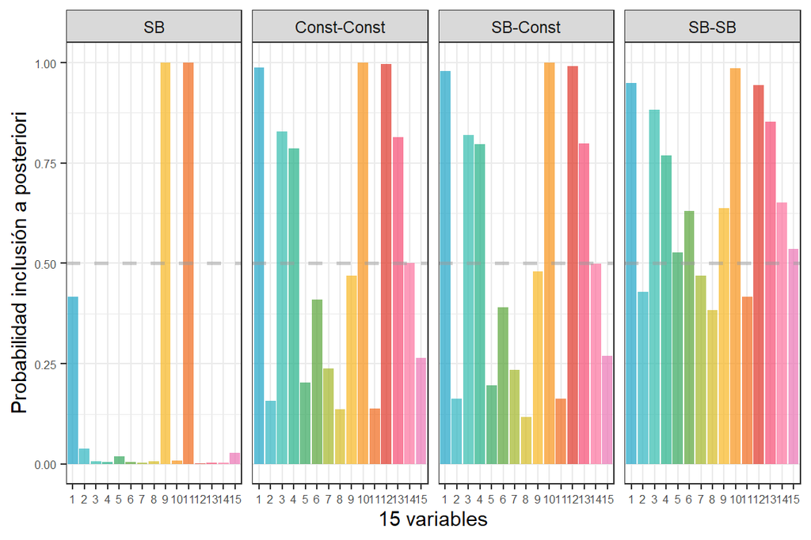

# Esperimento 3

Quiero ver qué pasa cuando aumento el número de variables falsas en cada grupo, manteniendo el mismo número de grupos, 4.

Los datos los genero con:

$\theta = 1 + \beta_1X_1+\beta_2X_2$, $\pi=\frac{e^{\theta}}{1 + e^{\theta}}$ e $Y\sim Ber(\pi)$. El primer grupo con 8 variables y el segundo con 4, no todas generan los datos.

Y luego añado 2 grupos falsos más con 8 y 4 variables cada uno. Se hace con n = 300 y n = 600 observaciones.

Con $\beta_1 = (0, 0, 0.55, 0.55, 0.55, 0.55, -0.49, -0.49)$, $\beta_2 = (0, 0, 0.46, 0.46)$ y n = 300 observaciones.

### Grupos

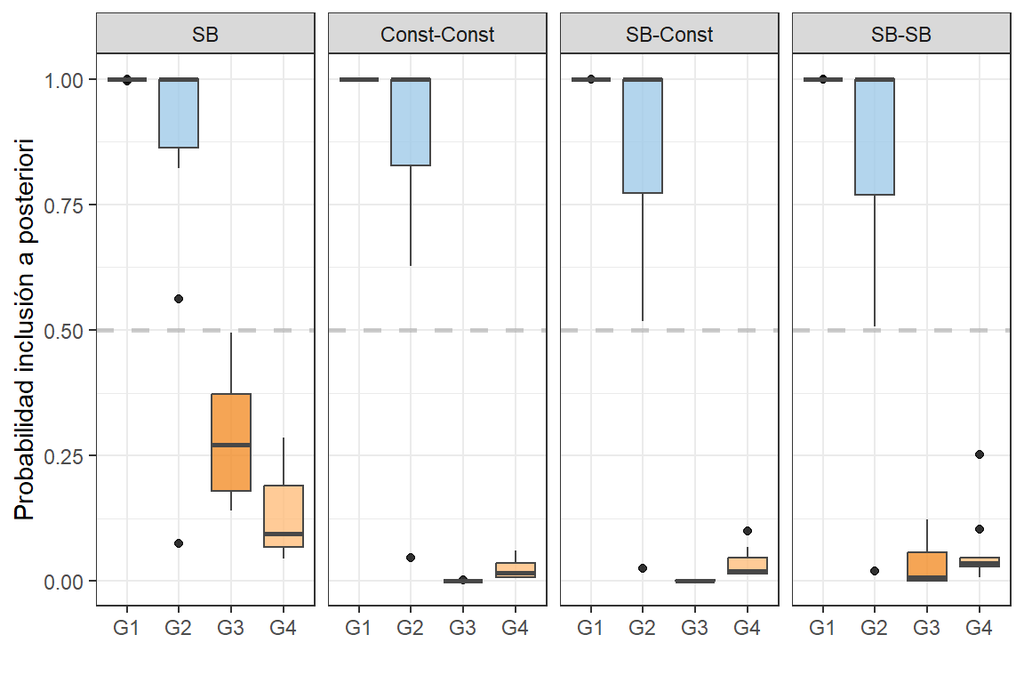

Porcentaje de grupos incorrectamente seleccionados e incorrectamente no seleccionados:

Porcentaje de grupos incorrectamente seleccionados para cada previa elegida.

|  | SB | Const-Const | SB-Const | SB-SB |
| --- | --- | --- | --- | --- |
| G3 | 0% | 0% | 0% | 0% |
| G4 | 0% | 0% | 0% | 0% |

Porcentaje de grupos incorrectamente no seleccionados para cada previa elegida.

|  | SB | Const-Const | SB-Const | SB-SB |
| --- | --- | --- | --- | --- |
| G1 | 0% | 0% | 0% | 0% |
| G2 | 10% | 10% | 10% | 10% |

Proporción de grupos incorrectamente seleccionados e incorrectamente no seleccionados del HPM.

| G1 | 0.0 |
| --- | --- |
| G2 | 0.3 |
| G3 | 0.0 |
| G4 | 0.0 |

### Variables agrupadas

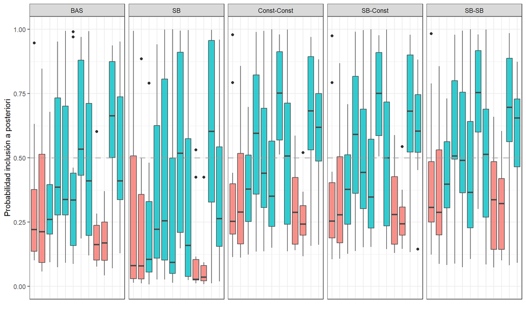

Porcentaje de variables agrupadas incorrectamente seleccionadas e incorrectamente no seleccionadas:

Porcentaje de variables agrupadas incorrectamente seleccionadas para cada previa elegida.

|  | G1 | G2 | G3 | G4 |
| --- | --- | --- | --- | --- |
| BAS | 25% | 5% | 0% | 0% |
| SB | 20% | 5% | 0% | 0% |
| Const-Const | 25% | 15% | 0% | 0% |
| SB-Const | 25% | 15% | 0% | 0% |
| SB-SB | 30% | 20% | 0% | 0% |

Porcentaje de variables agrupadas incorrectamente no seleccionadas para cada previa elegida.

|  | G1 | G2 |
| --- | --- | --- |
| BAS | 65% | 45% |
| SB | 70% | 50% |
| Const-Const | 50% | 25% |
| SB-Const | 50% | 25% |
| SB-SB | 50% | 25% |

Con n = 600 observaciones.

### Grupos

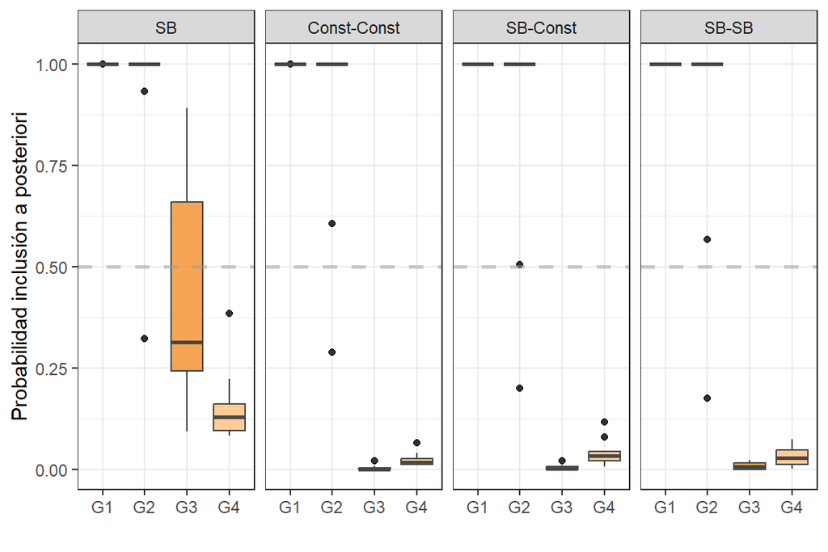

Porcentaje de grupos incorrectamente seleccionados e incorrectamente no seleccionados:

Porcentaje de grupos incorrectamente seleccionados para cada previa elegida.

|  | SB | Const-Const | SB-Const | SB-SB |
| --- | --- | --- | --- | --- |
| G3 | 30% | 0% | 0% | 0% |
| G4 | 0% | 0% | 0% | 0% |

Porcentaje de grupos incorrectamente no seleccionados para cada previa elegida.

|  | SB | Const-Const | SB-Const | SB-SB |
| --- | --- | --- | --- | --- |
| G1 | 0% | 0% | 0% | 0% |
| G2 | 10% | 10% | 10% | 10% |

Proporción de grupos incorrectamente seleccionadas e incorrectamente no seleccionados del HPM.

| G1 | 0.0 |
| --- | --- |
| G2 | 0.1 |
| G3 | 0.0 |
| G4 | 0.0 |

### Variables agrupadas

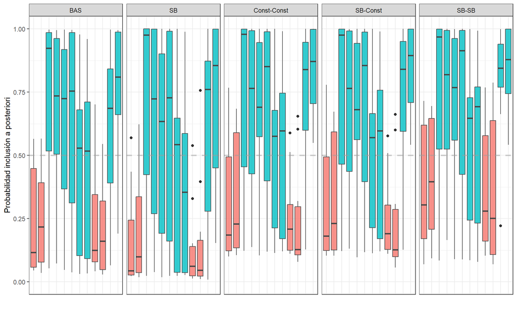

Porcentaje de variables agrupadas incorrectamente seleccionadas e incorrectamente no seleccionadas:

Porcentaje de variables agrupadas incorrectamente seleccionadas para cada previa elegida.

|  | G1 | G2 | G3 | G4 |
| --- | --- | --- | --- | --- |
| BAS | 20% | 10% | 3.75% | 0% |
| SB | 15% | 10% | 2.5% | 0% |
| Const-Const | 35% | 20% | 0% | 0% |
| SB-Const | 35% | 20% | 0% | 0% |
| SB-SB | 40% | 30% | 0% | 0% |

Porcentaje de variables agrupadas incorrectamente no seleccionadas para cada previa elegida.

|  | G1 | G2 |
| --- | --- | --- |
| BAS | 38.3333333333333% | 25% |
| SB | 43.3333333333333% | 35% |
| Const-Const | 35% | 20% |
| SB-Const | 33.3333333333333% | 20% |
| SB-SB | 31.6666666666667% | 15% |

Con $\beta_1 = (0.42, 0, 0, 0, 0, 0, 0, -0.4)$, $\beta_2 = (0.35, 0, 0, -0.3)$, con n = 300 observaciones.

### Grupos

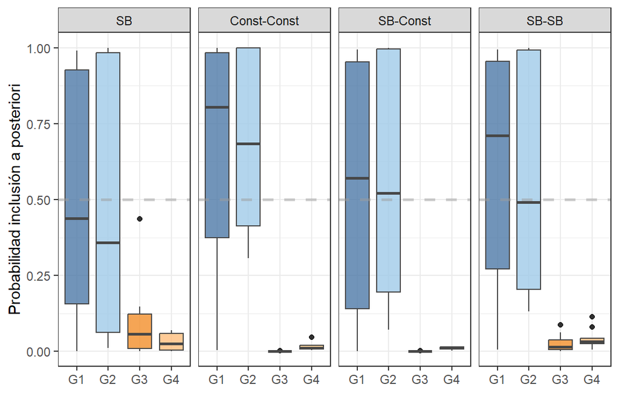

Porcentaje de grupos incorrectamente seleccionados e incorrectamente no seleccionados:

Porcentaje de grupos incorrectamente seleccionados para cada previa elegida.

|  | SB | Const-Const | SB-Const | SB-SB |
| --- | --- | --- | --- | --- |
| G3 | 0% | 0% | 0% | 0% |
| G4 | 0% | 0% | 0% | 0% |

Porcentaje de grupos incorrectamente no seleccionados para cada previa elegida.

|  | SB | Const-Const | SB-Const | SB-SB |
| --- | --- | --- | --- | --- |
| G1 | 50% | 40% | 50% | 40% |
| G2 | 60% | 40% | 50% | 50% |

Proporción de grupos incorrectamente seleccionadas e incorrectamente no seleccionados del HPM.

| G1 | 0.7 |
| --- | --- |
| G2 | 0.6 |
| G3 | 0.0 |
| G4 | 0.0 |

### Variables agrupadas

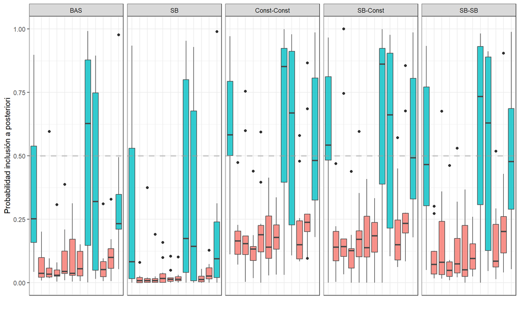

Porcentaje de variables agrupadas incorrectamente seleccionadas e incorrectamente no seleccionadas:

Porcentaje de variables agrupadas incorrectamente seleccionadas para cada previa elegida.

|  | G1 | G2 | G3 | G4 |
| --- | --- | --- | --- | --- |
| BAS | 5% | 0% | 0% | 0% |
| SB | 0% | 0% | 0% | 0% |
| Const-Const | 10% | 5% | 0% | 0% |
| SB-Const | 10% | 5% | 0% | 0% |
| SB-SB | 10% | 5% | 0% | 0% |

Porcentaje de variables agrupadas incorrectamente no seleccionadas para cada previa elegida.

|  | G1 | G2 |
| --- | --- | --- |
| BAS | 18.3333333333333% | 75% |
| SB | 23.3333333333333% | 80% |
| Const-Const | 16.6666666666667% | 65% |
| SB-Const | 20% | 70% |
| SB-SB | 20% | 70% |

Con n = 600 observaciones.

### Grupos

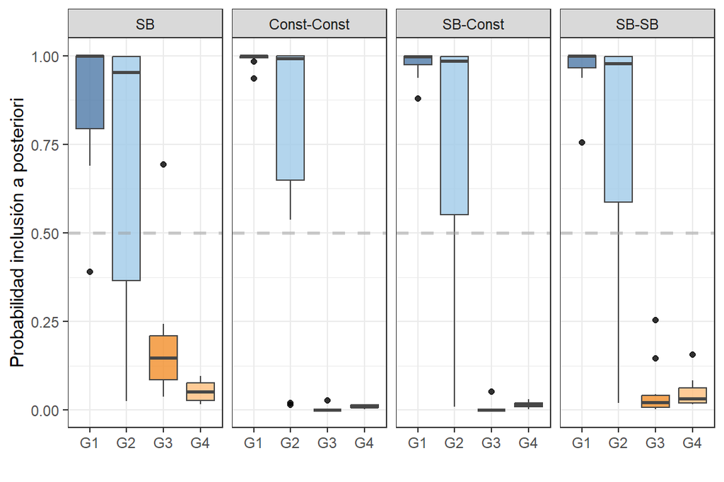

Porcentaje de grupos incorrectamente seleccionados e incorrectamente no seleccionados:

Porcentaje de grupos incorrectamente seleccionados para cada previa elegida.

|  | SB | Const-Const | SB-Const | SB-SB |
| --- | --- | --- | --- | --- |
| G3 | 10% | 0% | 0% | 0% |
| G4 | 0% | 0% | 0% | 0% |

Porcentaje de grupos incorrectamente no seleccionados para cada previa elegida.

|  | SB | Const-Const | SB-Const | SB-SB |
| --- | --- | --- | --- | --- |
| G1 | 10% | 0% | 0% | 0% |
| G2 | 30% | 20% | 30% | 30% |

Proporción de grupos incorrectamente seleccionadas e incorrectamente no seleccionados del HPM.

| G1 | 0.0 |
| --- | --- |
| G2 | 0.3 |
| G3 | 0.0 |
| G4 | 0.0 |

### Variables agrupadas

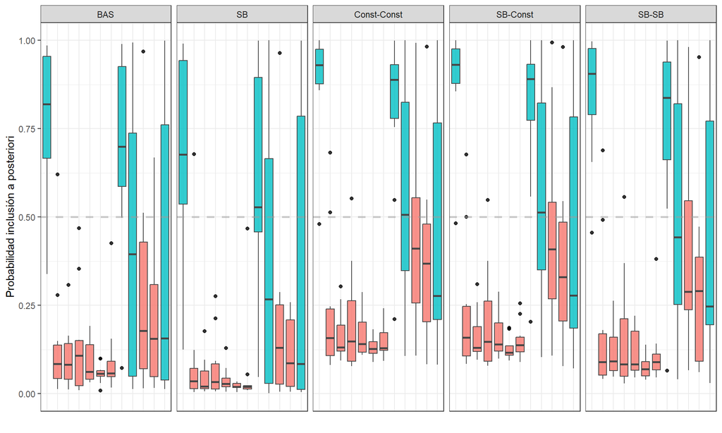

Porcentaje de variables agrupadas incorrectamente seleccionadas e incorrectamente no seleccionadas:

Porcentaje de variables agrupadas incorrectamente seleccionadas para cada previa elegida.

|  | G1 | G2 | G3 | G4 |
| --- | --- | --- | --- | --- |
| BAS | 5% | 15% | 1.25% | 0% |
| SB | 5% | 5% | 0% | 0% |
| Const-Const | 15% | 30% | 0% | 0% |
| SB-Const | 15% | 30% | 0% | 0% |
| SB-SB | 10% | 20% | 0% | 0% |

Porcentaje de variables agrupadas incorrectamente no seleccionadas para cada previa elegida.

|  | G1 | G2 |
| --- | --- | --- |
| BAS | 5% | 60% |
| SB | 8.33333333333333% | 65% |
| Const-Const | 3.33333333333333% | 55% |
| SB-Const | 3.33333333333333% | 55% |
| SB-SB | 3.33333333333333% | 60% |

### Frecuentista

Proporción de grupos incorrectamente seleccionados e incorrectamente no seleccionados con gLasso para el primer banco de datos con n = 300.

| G1 | 0.4 |
| --- | --- |
| G2 | 0.3 |
| G3 | 0.0 |
| G4 | 0.0 |

Proporción de grupos incorrectamente seleccionados e incorrectamente no seleccionados con gLasso para el primer banco de datos con n = 600.

| G1 | 0.1 |
| --- | --- |
| G2 | 0.1 |
| G3 | 0.2 |
| G4 | 0.1 |

Proporción de grupos incorrectamente seleccionados e incorrectamente no seleccionados con gLasso para el segundo banco de datos con n = 300.

| G1 | 0.9 |
| --- | --- |
| G2 | 0.8 |
| G3 | 0.0 |
| G4 | 0.0 |

Proporción de grupos incorrectamente seleccionados e incorrectamente no seleccionados con gLasso para el segundo banco de datos con n = 600.

| G1 | 0.7 |
| --- | --- |
| G2 | 0.6 |
| G3 | 0.0 |
| G4 | 0.0 |

Proporción de grupos incorrectamente seleccionados e incorrectamente no seleccionados con gMCP para el primer banco de datos con n = 300.

| G1 | 0.3 |
| --- | --- |
| G2 | 0.5 |
| G3 | 0.0 |
| G4 | 0.0 |

Proporción de grupos incorrectamente seleccionados e incorrectamente no seleccionados con gMCP para el primer banco de datos con n = 600.

| G1 | 0.1 |
| --- | --- |
| G2 | 0.3 |
| G3 | 0.0 |
| G4 | 0.0 |

Proporción de grupos incorrectamente seleccionados e incorrectamente no seleccionados con gMCP para el segundo banco de datos con n = 300.

| G1 | 1.0 |
| --- | --- |
| G2 | 0.8 |
| G3 | 0.0 |
| G4 | 0.0 |

Proporción de grupos incorrectamente seleccionados e incorrectamente no seleccionados con gMCP para el segundo banco de datos con n = 600.

| G1 | 0.7 |
| --- | --- |
| G2 | 0.6 |
| G3 | 0.0 |
| G4 | 0.0 |

Proporción de grupos incorrectamente seleccionados e incorrectamente no seleccionados con gSCAD para el primer banco de datos con n = 300.

| G1 | 0.3 |
| --- | --- |
| G2 | 0.3 |
| G3 | 0.0 |
| G4 | 0.0 |

Proporción de grupos incorrectamente seleccionados e incorrectamente no seleccionados con gSCAD para el primer banco de datos con n = 600.

| G1 | 0.1 |
| --- | --- |
| G2 | 0.3 |
| G3 | 0.1 |
| G4 | 0.0 |

Proporción de grupos incorrectamente seleccionados e incorrectamente no seleccionados con gSCAD para el segundo banco de datos con n = 300.

| G1 | 0.9 |
| --- | --- |
| G2 | 0.8 |
| G3 | 0.0 |
| G4 | 0.0 |

Proporción de grupos incorrectamente seleccionados e incorrectamente no seleccionados con gSCAD para el segundo banco de datos con n = 600.

| G1 | 0.7 |
| --- | --- |
| G2 | 0.6 |
| G3 | 0.1 |
| G4 | 0.0 |

# Experimento 4

## Experimento 4.0

Los datos los genero con:

$\theta = 1 + \beta_1X_1 + \beta_2X_2+ \beta_3X_3$, $\pi=\frac{e^{\theta}}{1 + e^{\theta}}$ e $Y\sim Ber(\pi)$.

Los coeficientes de los grupos los genero con una normal de media 0.5 y desviación típica 0.1, 0.15, 0.2, respectivamente.

### Grupos

En general:

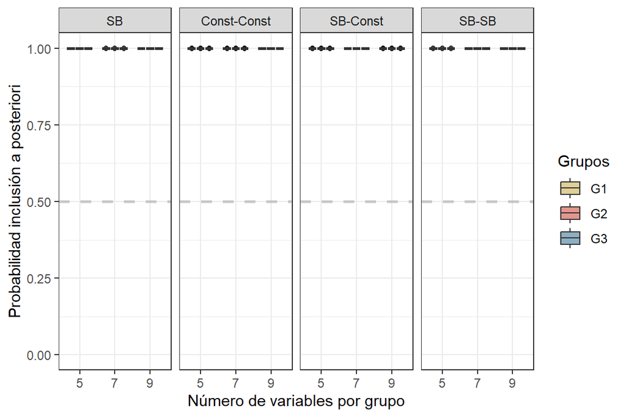

### Variables agrupadas

En general:

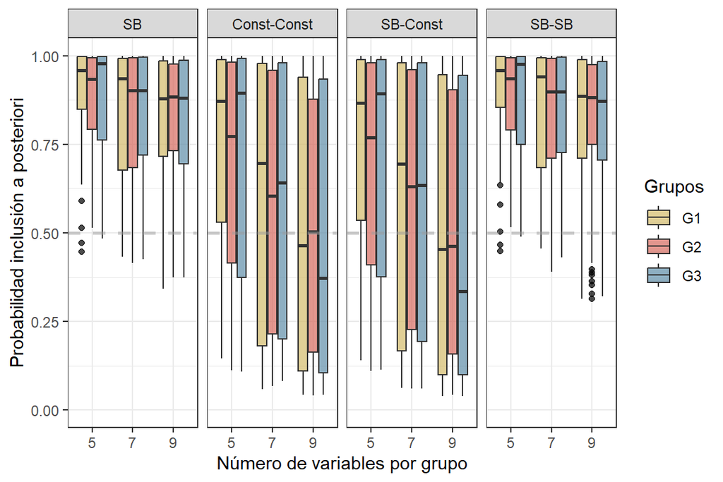

En función del número de variables:

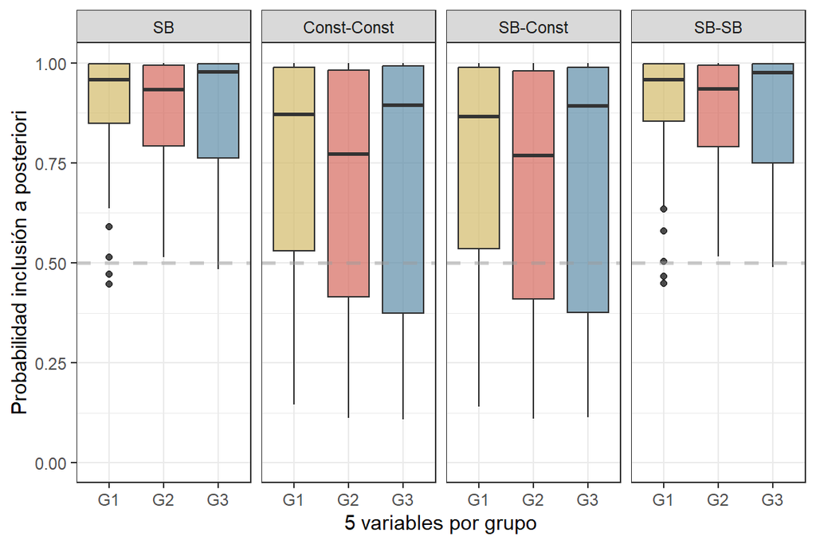

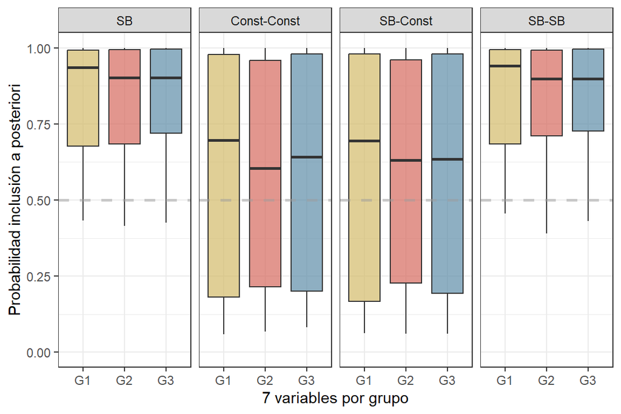

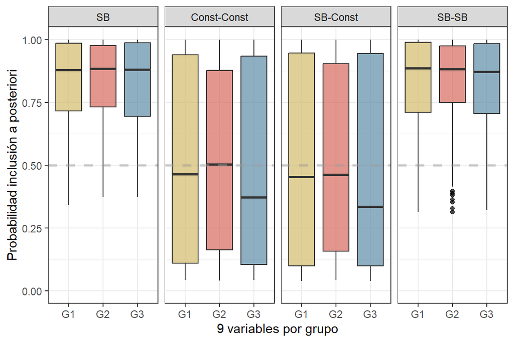

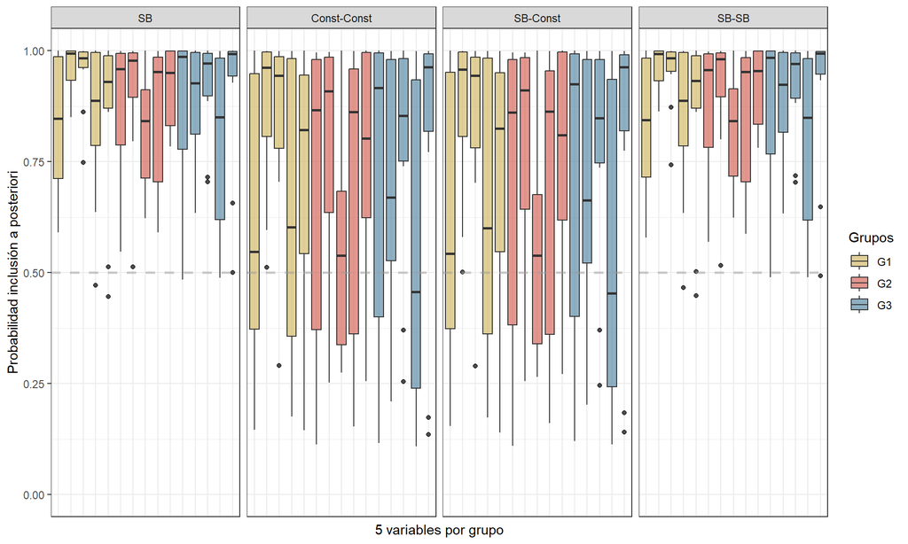

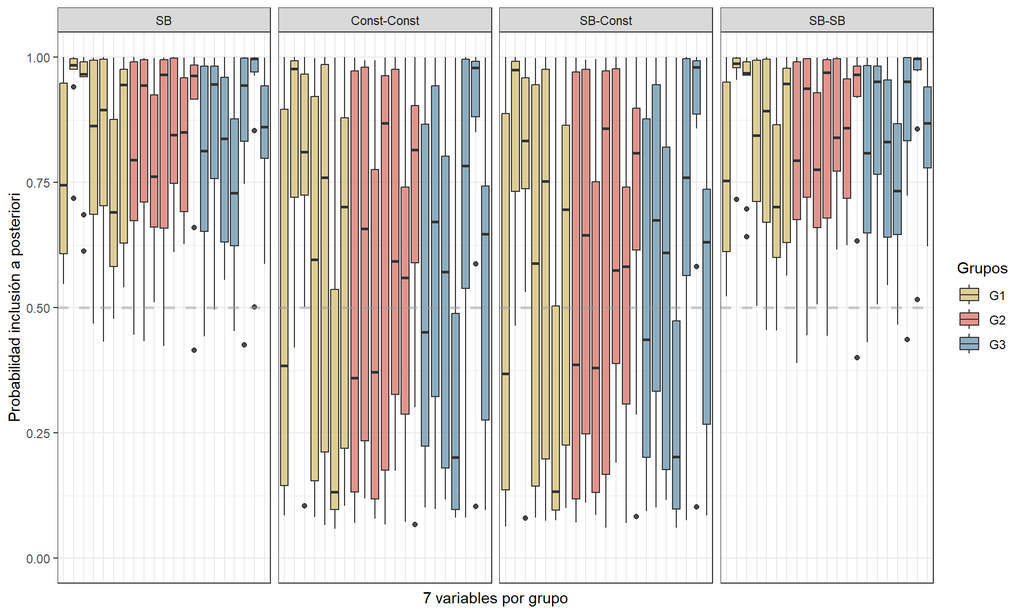

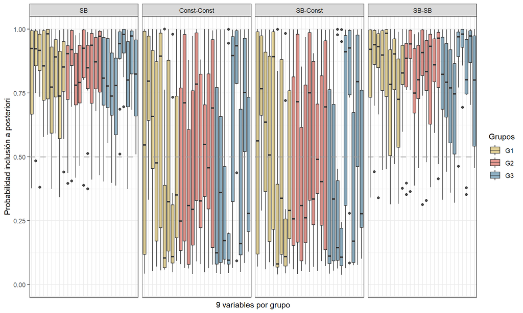

Porcentaje de variables agrupadas incorrectamente no seleccionados:

Porcentaje de variables agrupadas incorrectamente no seleccionadas para SB.

|  | G1 | G2 | G3 |
| --- | --- | --- | --- |
| Num vars = 5 | 4% | 0% | 4% |
| Num vars = 7 | 7.14285714285714% | 5.71428571428571% | 7.14285714285714% |
| Num vars = 9 | 7.77777777777778% | 10% | 7.77777777777778% |

Porcentaje de variables agrupadas incorrectamente no seleccionadas para Const-Const.

|  | G1 | G2 | G3 |
| --- | --- | --- | --- |
| Num vars = 5 | 22% | 28% | 30% |
| Num vars = 7 | 38.5714285714286% | 48.5714285714286% | 40% |
| Num vars = 9 | 53.3333333333333% | 50% | 53.3333333333333% |

Porcentaje de variables agrupadas incorrectamente no seleccionadas para SB-Const.

|  | G1 | G2 | G3 |
| --- | --- | --- | --- |
| Num vars = 5 | 22% | 28% | 30% |
| Num vars = 7 | 38.5714285714286% | 48.5714285714286% | 40% |
| Num vars = 9 | 52.2222222222222% | 52.2222222222222% | 56.6666666666667% |

Porcentaje de variables agrupadas incorrectamente no seleccionadas para SB-SB.

|  | G1 | G2 | G3 |
| --- | --- | --- | --- |
| Num vars = 5 | 4% | 0% | 6% |
| Num vars = 7 | 5.71428571428571% | 5.71428571428571% | 5.71428571428571% |
| Num vars = 9 | 15.5555555555556% | 14.4444444444444% | 15.5555555555556% |

### Con BAS

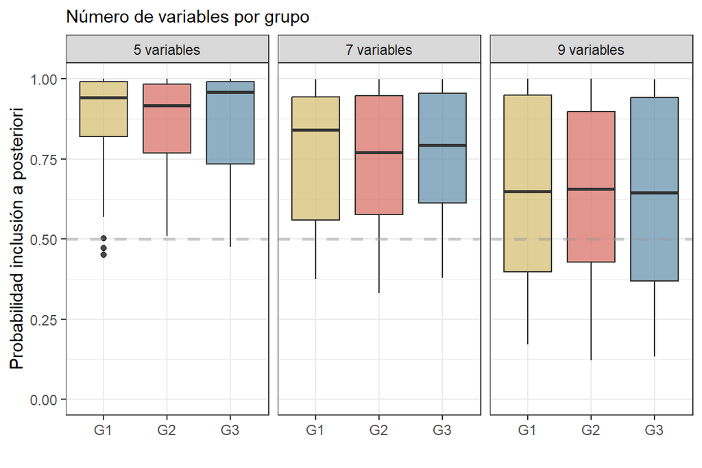

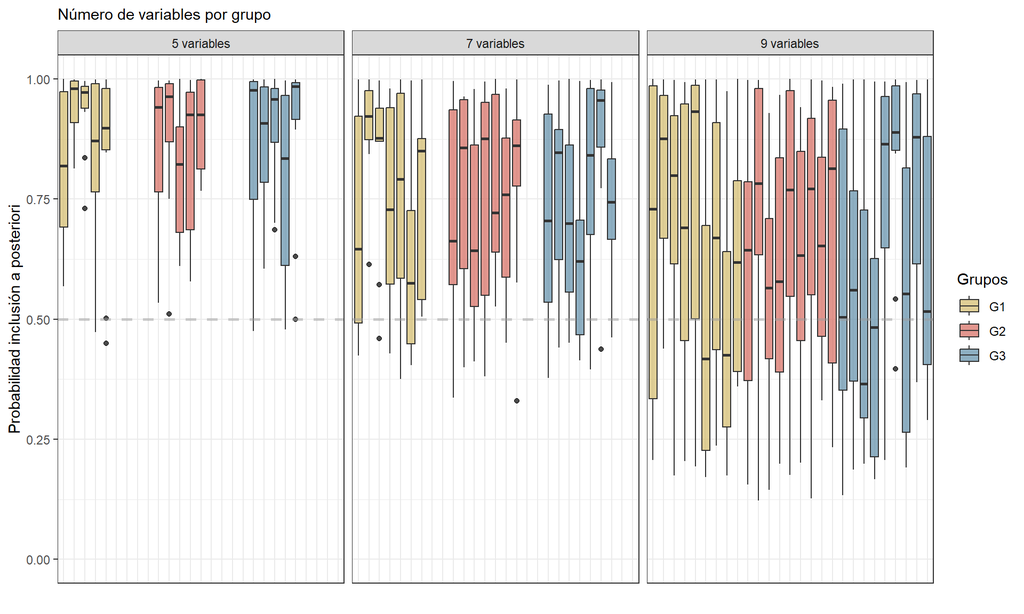

## Experimento 4.1

Los datos los genero con:

$\theta = 1 + \beta_1X_1 + \beta_2X_2+ \beta_3X_3$, $\pi=\frac{e^{\theta}}{1 + e^{\theta}}$ e $Y\sim Ber(\pi)$.

Los coeficientes de los grupos los genero con una normal de media 0.5 y desviación típica 0.1, 0.15, 0.2, respectivamente.

Generamos los datos cambiando la correlación de las variables de los grupos. Lo hago para $\rho =$ 0.5, 0.6, 0.7 y 0.8. Lo repito todo 5 veces.

### Grupos

En general:

[figure not shown]

### Variables agrupadas

En general:

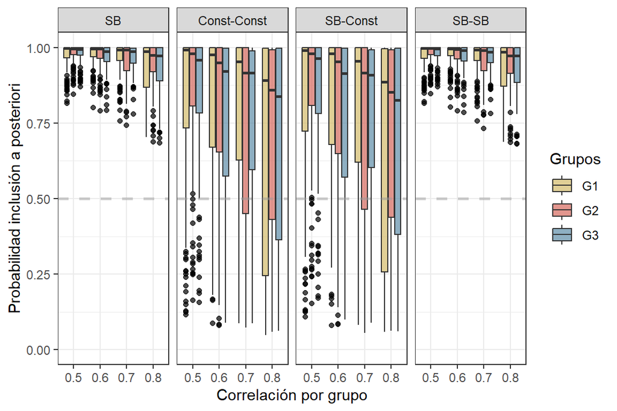

En función de la correlación:

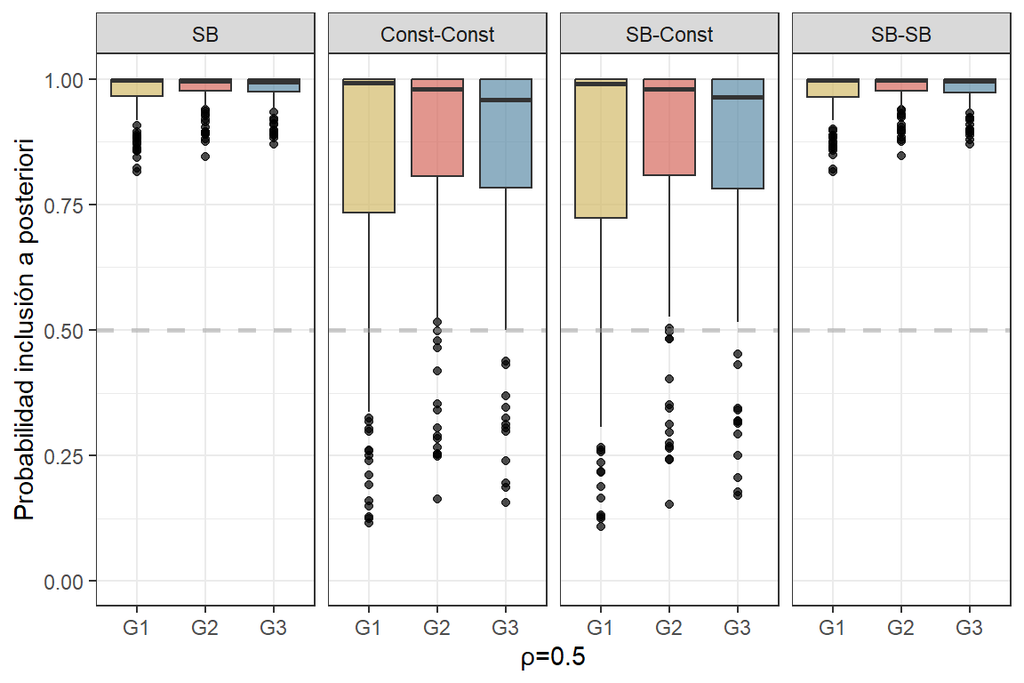

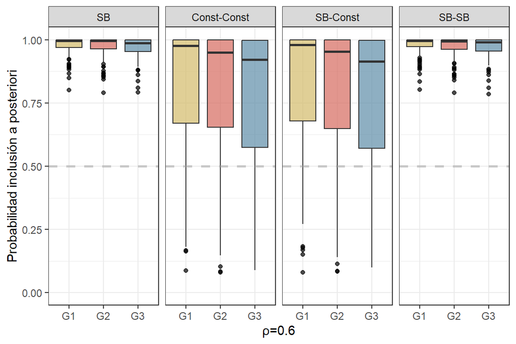

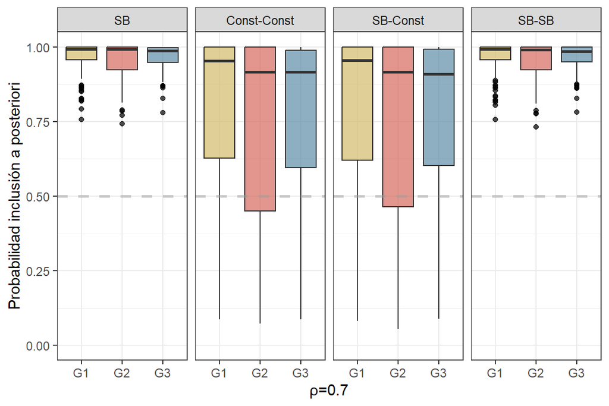

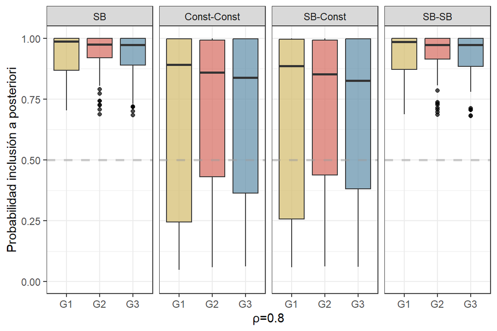

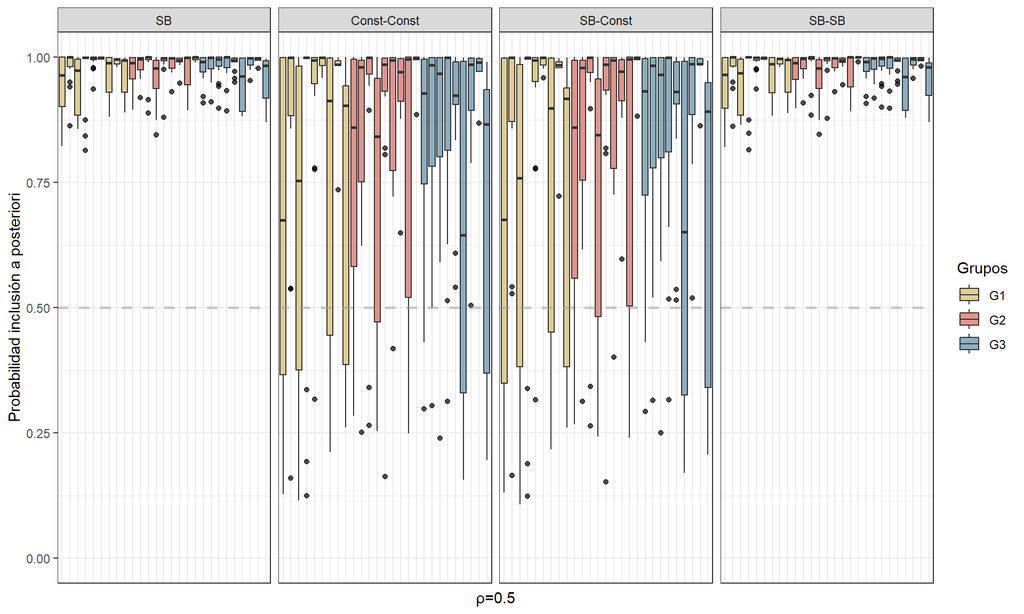

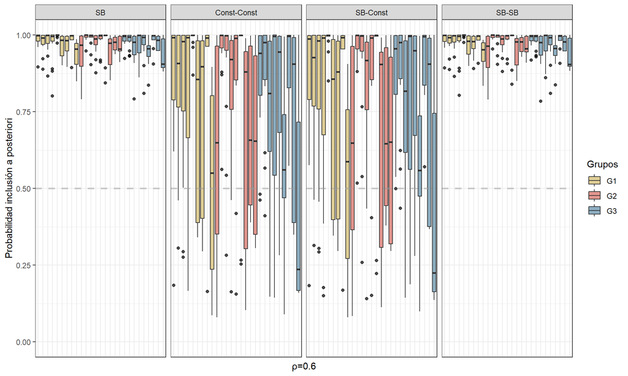

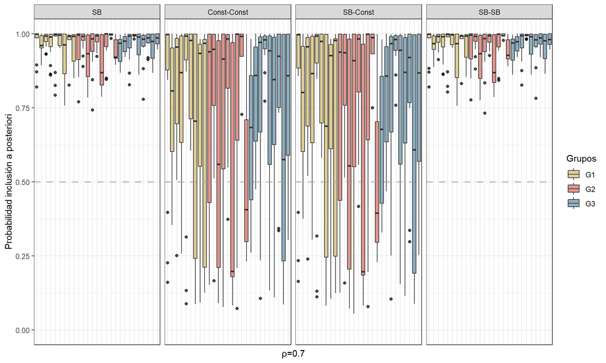

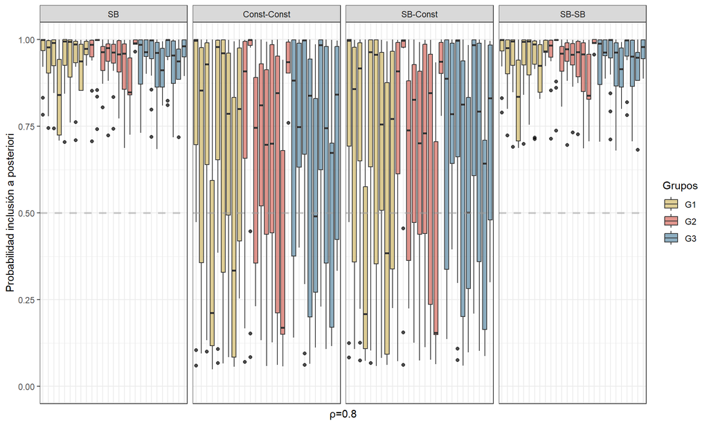

Porcentaje de variables agrupadas incorrectamente no seleccionadas:

Porcentaje de variables agrupadas incorrectamente no seleccionadas para SB.

|  | G1 | G2 | G3 |
| --- | --- | --- | --- |
| ρ=0.5 | 0% | 0% | 0% |
| ρ=0.6 | 0% | 0% | 0% |
| ρ=0.7 | 0% | 0% | 0% |
| ρ=0.8 | 0% | 0% | 0% |

Porcentaje de variables agrupadas incorrectamente no seleccionadas para Const-Const.

|  | G1 | G2 | G3 |
| --- | --- | --- | --- |
| ρ=0.5 | 19.047619047619% | 13.3333333333333% | 12.3809523809524% |
| ρ=0.6 | 18.0952380952381% | 18.0952380952381% | 20% |
| ρ=0.7 | 19.047619047619% | 27.6190476190476% | 18.0952380952381% |
| ρ=0.8 | 36.1904761904762% | 31.4285714285714% | 37.1428571428571% |

Porcentaje de variables agrupadas incorrectamente no seleccionadas para SB-Const.

|  | G1 | G2 | G3 |
| --- | --- | --- | --- |
| ρ=0.5 | 19.047619047619% | 13.3333333333333% | 11.4285714285714% |
| ρ=0.6 | 18.0952380952381% | 18.0952380952381% | 20% |
| ρ=0.7 | 19.047619047619% | 27.6190476190476% | 18.0952380952381% |
| ρ=0.8 | 36.1904761904762% | 31.4285714285714% | 36.1904761904762% |

Porcentaje de variables agrupadas incorrectamente no seleccionadas para SB-SB.

|  | G1 | G2 | G3 |
| --- | --- | --- | --- |
| ρ=0.5 | 0% | 0% | 0% |
| ρ=0.6 | 0% | 0% | 0% |
| ρ=0.7 | 0% | 0% | 0% |
| ρ=0.8 | 0% | 0% | 0% |

## Experimento 4.2

Los datos los genero con:

$\theta = 1 + \beta_1X_1 + \beta_2X_2+ \beta_3X_3$, $\pi=\frac{e^{\theta}}{1 + e^{\theta}}$ e $Y\sim Ber(\pi)$.

Los coeficientes de los grupos los genero con una normal de media 0.2 y desviación típica 0.1, 0.15, 0.2, respectivamente

### Grupos

En general:

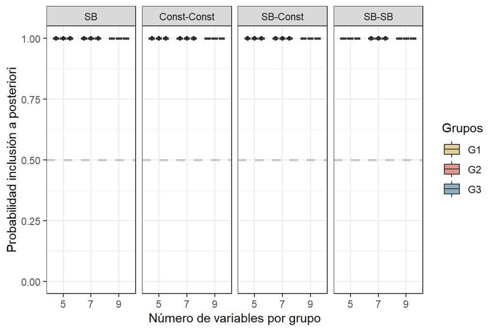

### Variables agrupadas

En general:

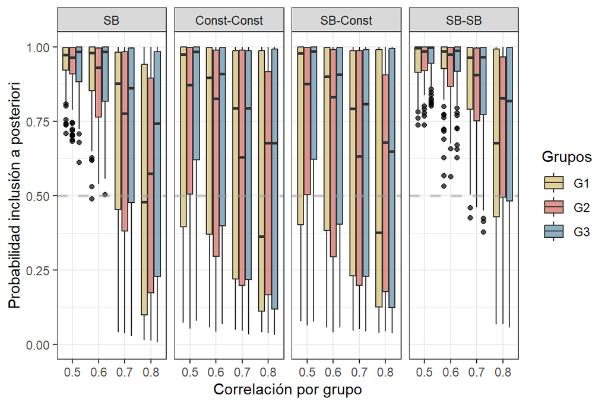

En función de la correlación:

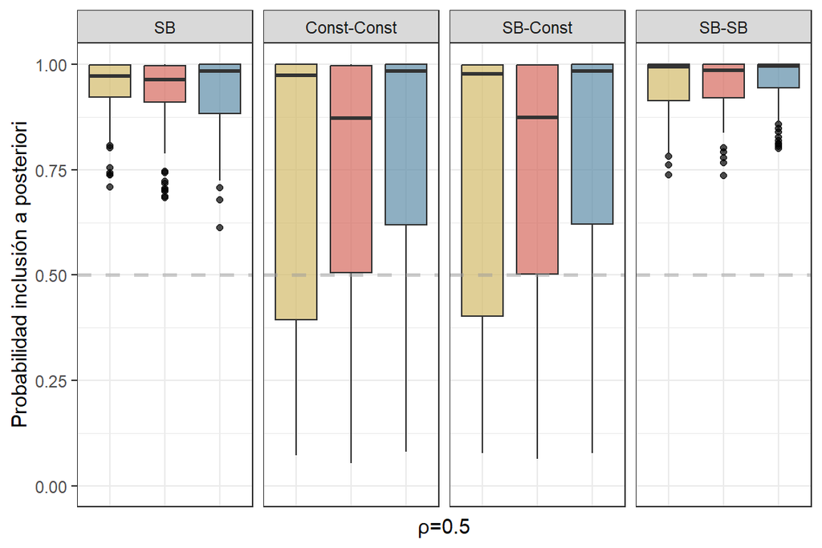

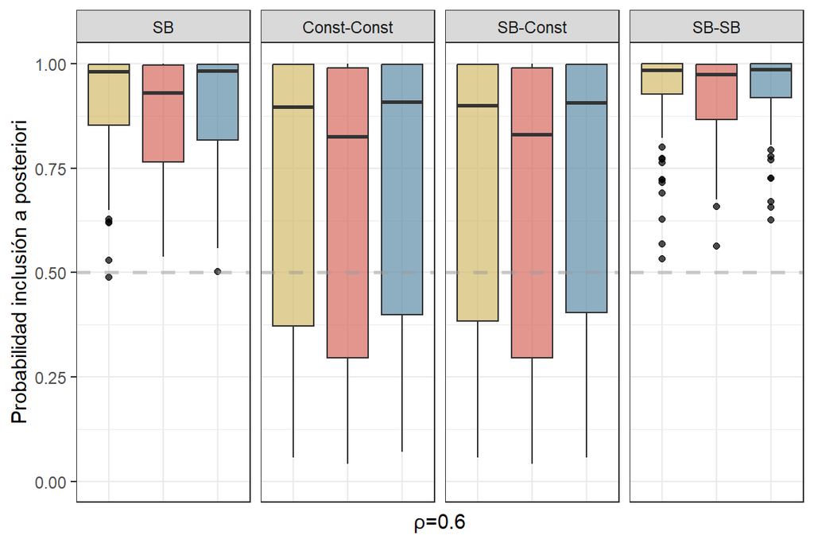

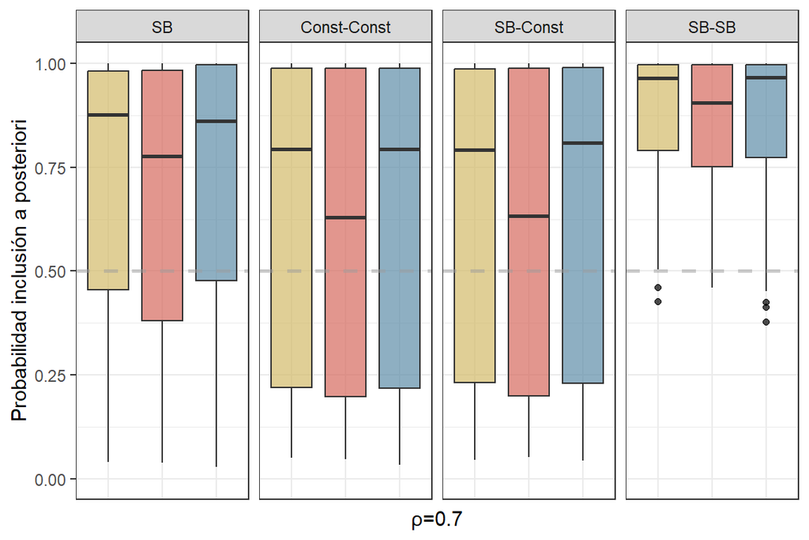

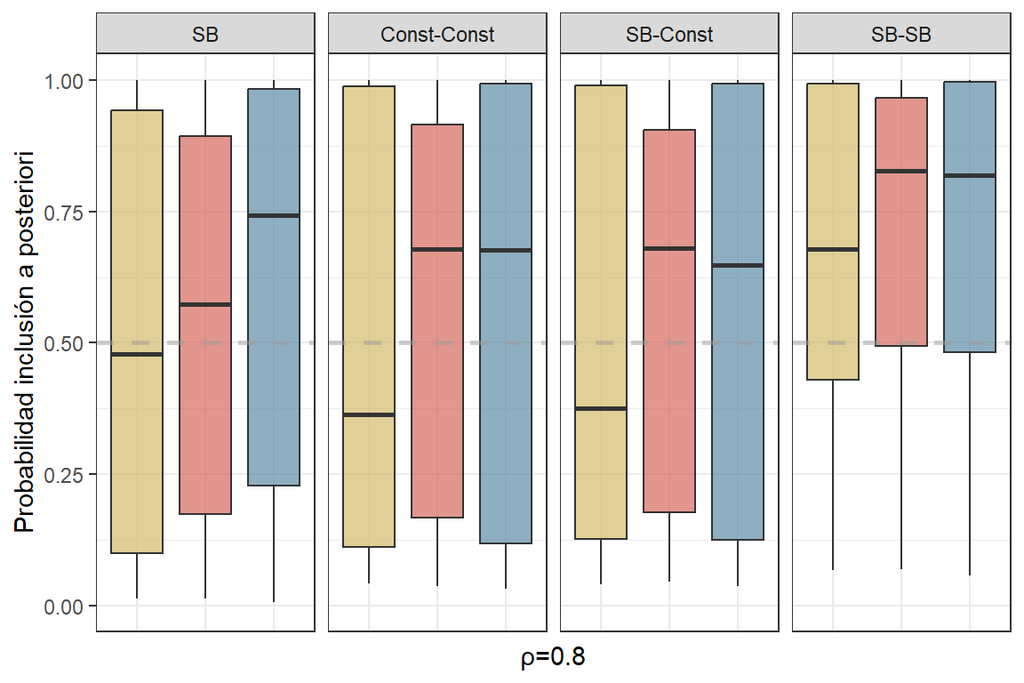

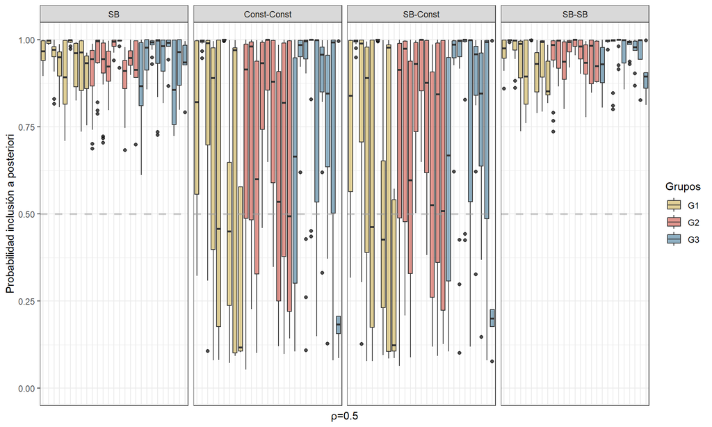

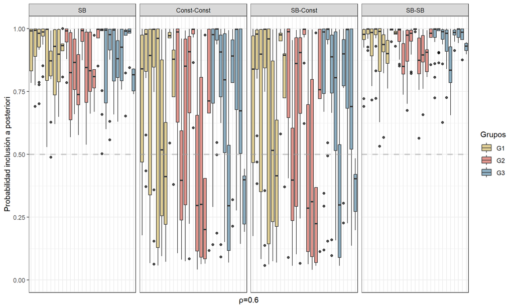

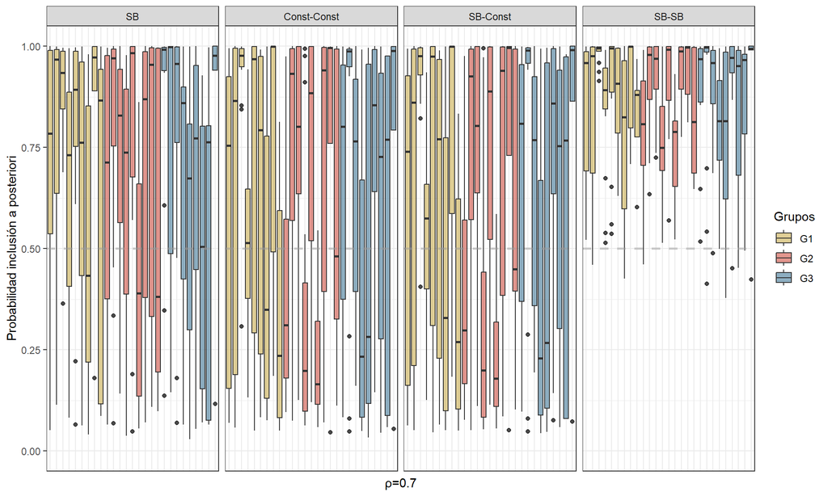

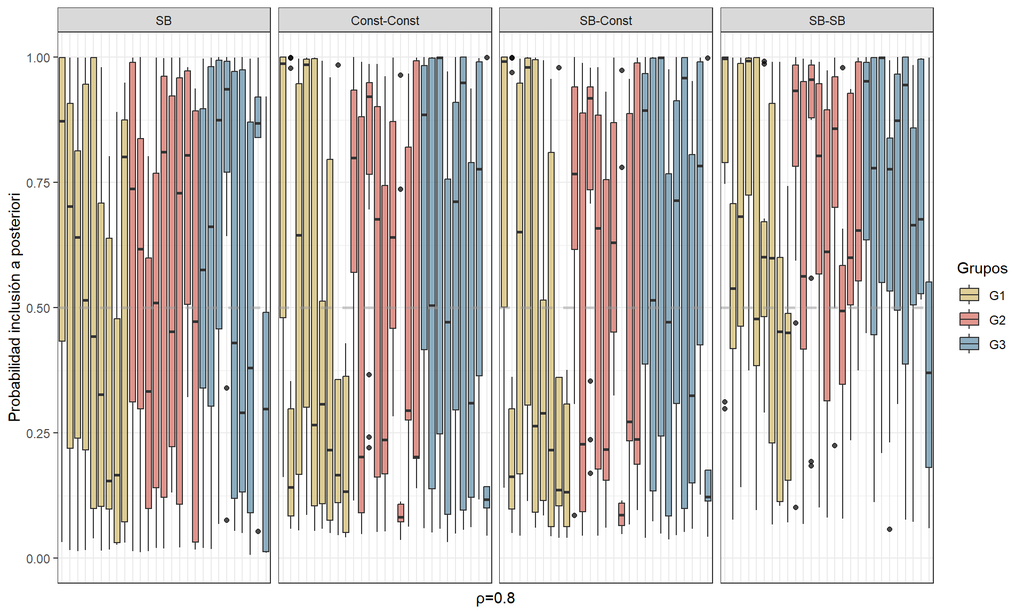

Porcentaje de variables agrupadas incorrectamente no seleccionadas:

Porcentaje de variables agrupadas incorrectamente no seleccionadas para SB.

|  | G1 | G2 | G3 |
| --- | --- | --- | --- |
| ρ=0.5 | 0% | 0% | 0% |
| ρ=0.6 | 0.952380952380952% | 0% | 0% |
| ρ=0.7 | 25.7142857142857% | 28.5714285714286% | 28.5714285714286% |
| ρ=0.8 | 50.4761904761905% | 46.6666666666667% | 40.9523809523809% |

Porcentaje de variables agrupadas incorrectamente no seleccionadas para Const-Const.

|  | G1 | G2 | G3 |
| --- | --- | --- | --- |
| ρ=0.5 | 28.5714285714286% | 24.7619047619048% | 21.9047619047619% |
| ρ=0.6 | 31.4285714285714% | 38.0952380952381% | 29.5238095238095% |
| ρ=0.7 | 37.1428571428571% | 44.7619047619048% | 40.9523809523809% |
| ρ=0.8 | 56.1904761904762% | 43.8095238095238% | 44.7619047619048% |

Porcentaje de variables agrupadas incorrectamente no seleccionadas para SB-Const.

|  | G1 | G2 | G3 |
| --- | --- | --- | --- |
| ρ=0.5 | 29.5238095238095% | 23.8095238095238% | 22.8571428571429% |
| ρ=0.6 | 31.4285714285714% | 37.1428571428571% | 29.5238095238095% |
| ρ=0.7 | 34.2857142857143% | 44.7619047619048% | 40.9523809523809% |
| ρ=0.8 | 55.2380952380952% | 43.8095238095238% | 44.7619047619048% |

Porcentaje de variables agrupadas incorrectamente no seleccionadas para SB-SB.

|  | G1 | G2 | G3 |
| --- | --- | --- | --- |
| ρ=0.5 | 0% | 0% | 0% |
| ρ=0.6 | 0% | 0% | 0% |
| ρ=0.7 | 1.9047619047619% | 0.952380952380952% | 7.61904761904762% |
| ρ=0.8 | 32.3809523809524% | 26.6666666666667% | 25.7142857142857% |

## Experimento 4.3

Como en 4.0 pero cambiando la correlación de los grupos a 0.2, 0.8 y 0.8, respectivamente. Los datos los genero con:

$\theta = 1 + \beta_1X_1 + \beta_2X_2+ \beta_3X_3$, $\pi=\frac{e^{\theta}}{1 + e^{\theta}}$ e $Y\sim Ber(\pi)$.

Los coeficientes los genero de una normal de media 0.5 y desviación típica de 0.1, 0.15 y 0.2, respectivamente.

### Grupos

En general:

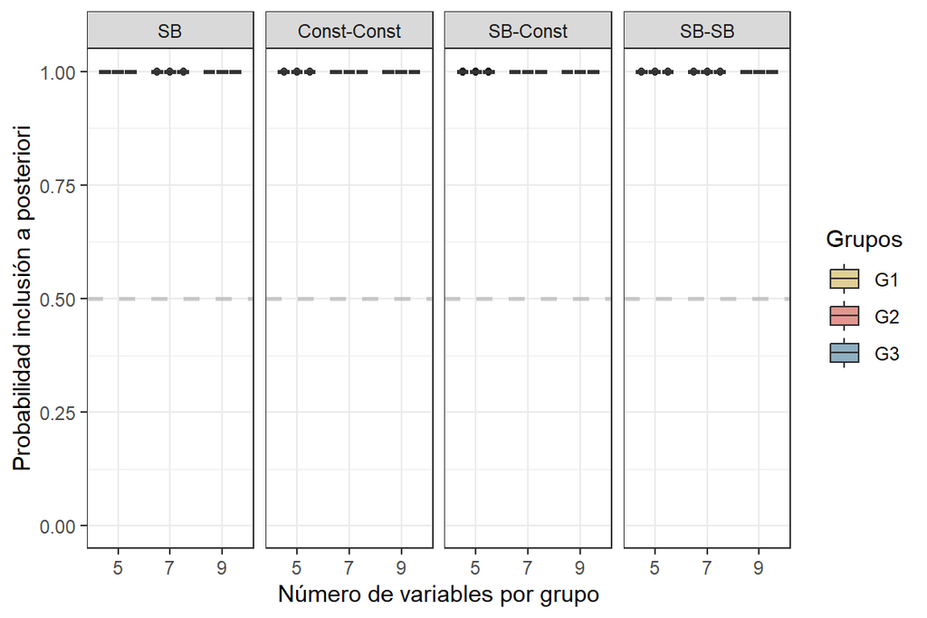

### Variables agrupadas

En general:

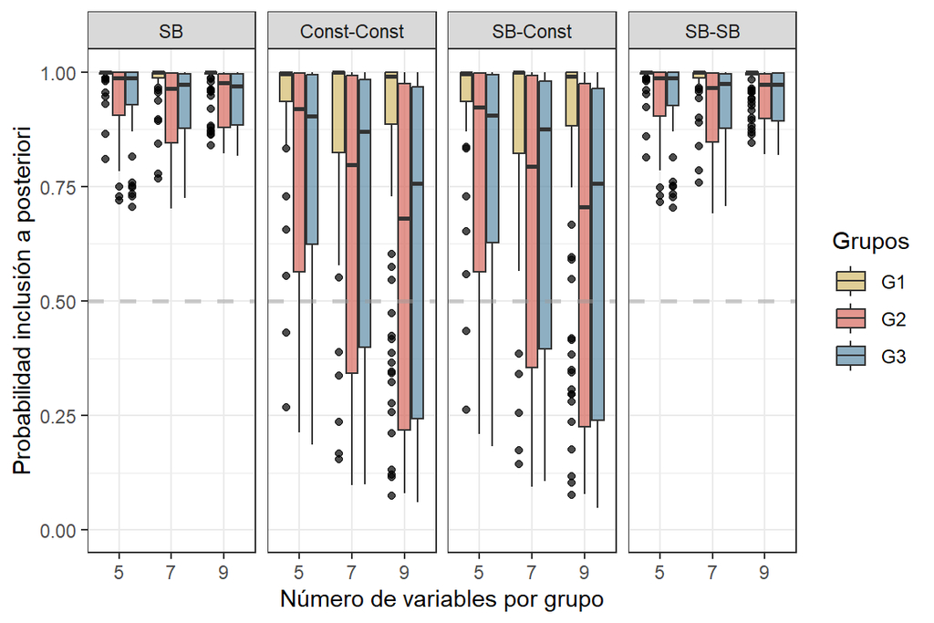

En función del número de variables:

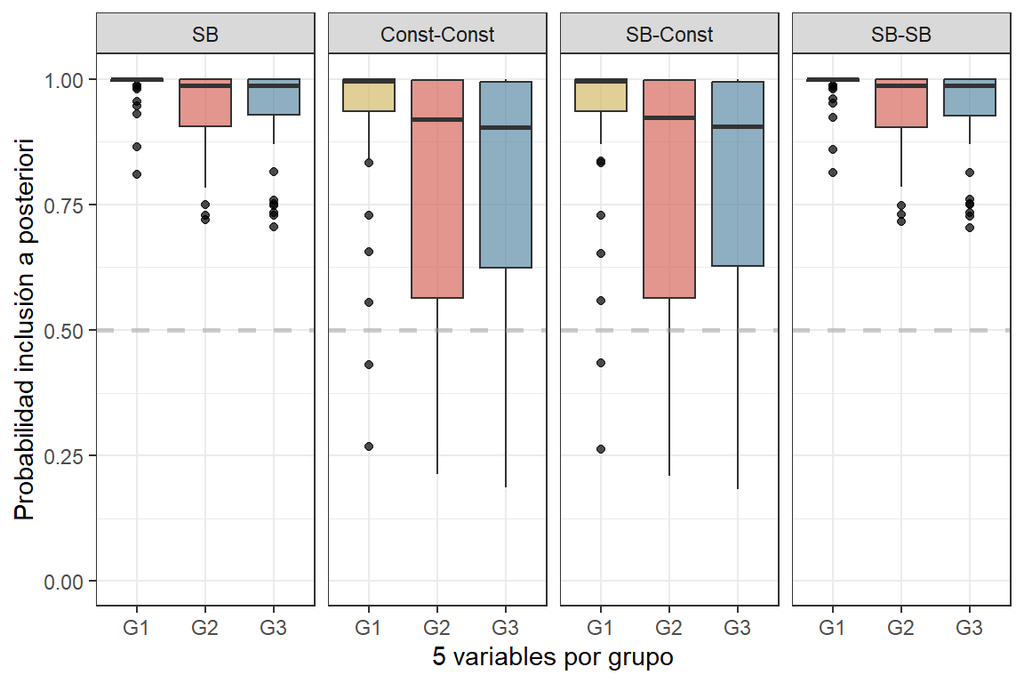

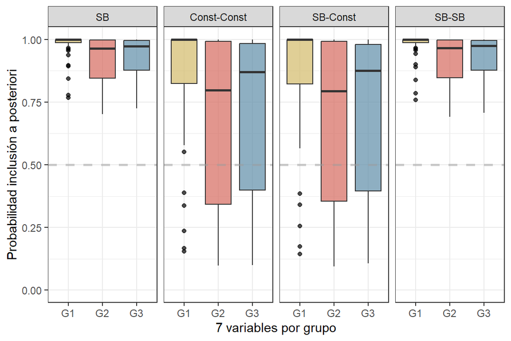

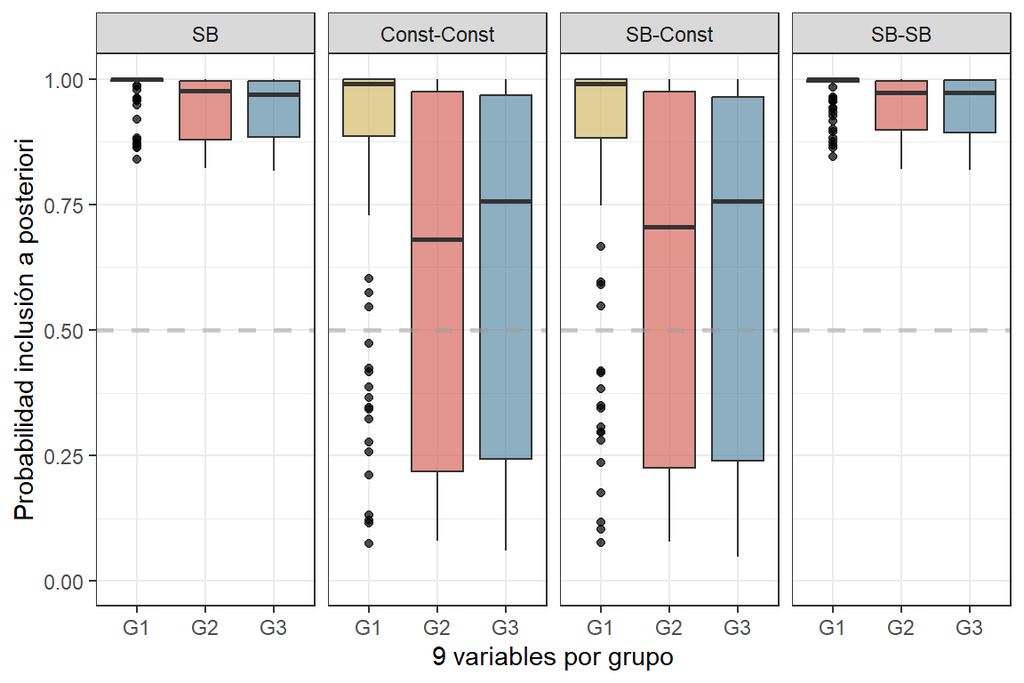

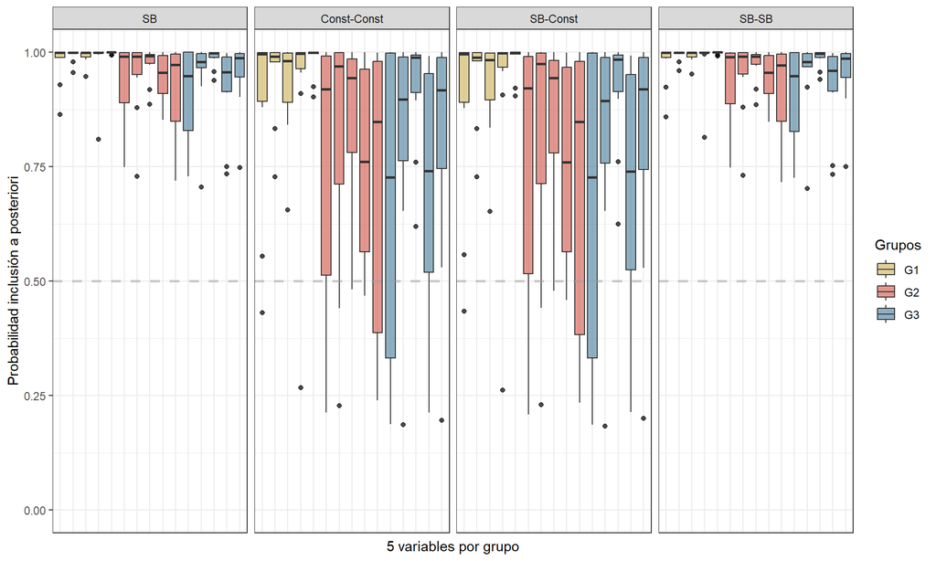

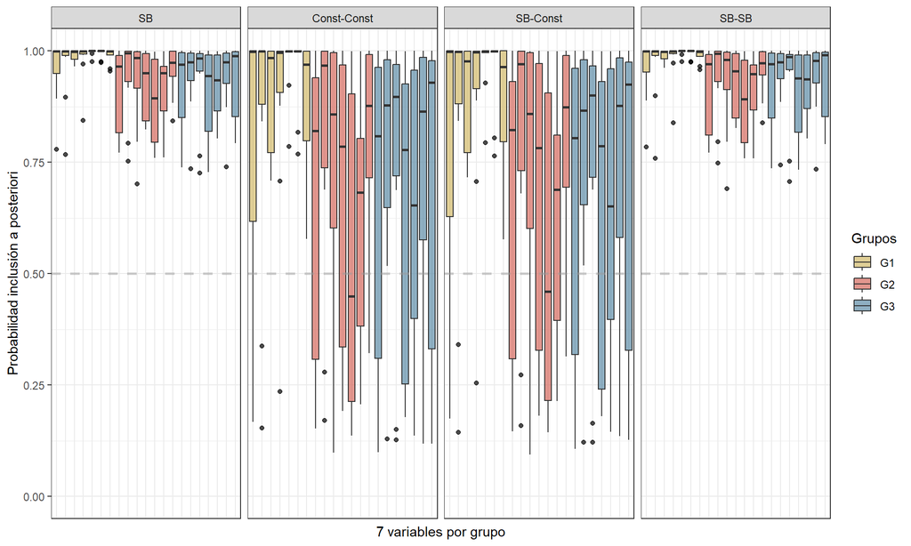

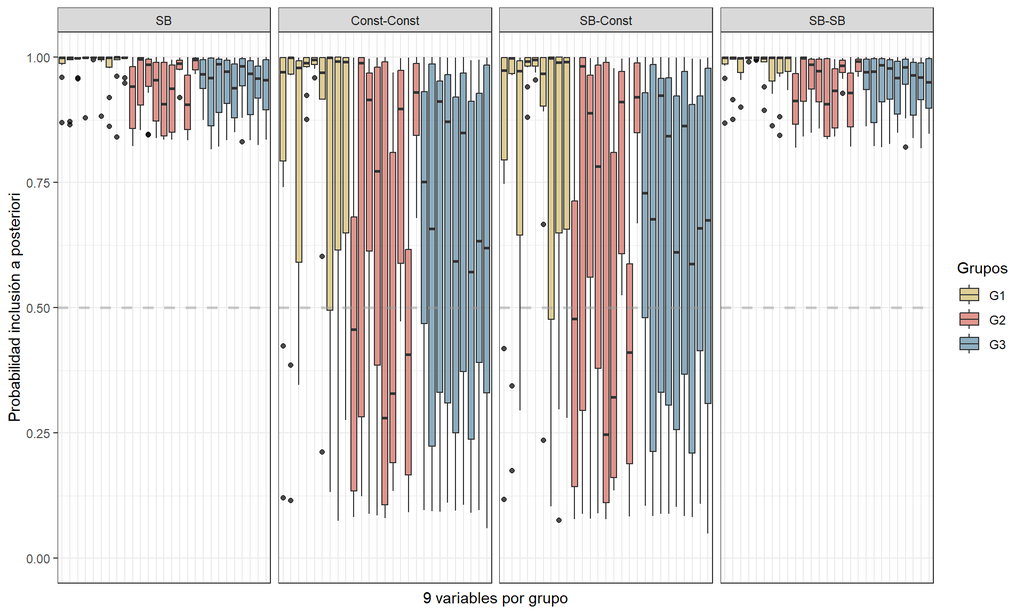

Porcentaje de variables agrupadas incorrectamente no seleccionados:

Porcentaje de variables agrupadas incorrectamente no seleccionadas para SB.

|  | G1 | G2 | G3 |
| --- | --- | --- | --- |
| Num vars = 5 | 0% | 0% | 0% |
| Num vars = 7 | 0% | 0% | 0% |
| Num vars = 9 | 0% | 0% | 0% |

Porcentaje de variables agrupadas incorrectamente no seleccionadas para Const-Const.

|  | G1 | G2 | G3 |
| --- | --- | --- | --- |
| Num vars = 5 | 4% | 24% | 16% |
| Num vars = 7 | 7.14285714285714% | 31.4285714285714% | 30% |
| Num vars = 9 | 16.6666666666667% | 36.6666666666667% | 37.7777777777778% |

Porcentaje de variables agrupadas incorrectamente no seleccionadas para SB-Const.

|  | G1 | G2 | G3 |
| --- | --- | --- | --- |
| Num vars = 5 | 4% | 24% | 16% |
| Num vars = 7 | 7.14285714285714% | 30% | 30% |
| Num vars = 9 | 15.5555555555556% | 35.5555555555556% | 35.5555555555556% |

Porcentaje de variables agrupadas incorrectamente no seleccionadas para SB-SB.

|  | G1 | G2 | G3 |
| --- | --- | --- | --- |
| Num vars = 5 | 0% | 0% | 0% |
| Num vars = 7 | 0% | 0% | 0% |
| Num vars = 9 | 0% | 0% | 0% |

## Experimento 4.4

Los datos los genero con:

$\theta = 1 + \beta_1X_1 + \beta_2X_2+ \beta_3X_3$, $\pi=\frac{e^{\theta}}{1 + e^{\theta}}$ e $Y\sim Ber(\pi)$.

Los coeficientes de los grupos los genero con una normal de media 0.5 y desviación típica 0.1, 0.15, 0.2, respectivamente.

Como en 4.0 con una correlación de 0.75 para las variables de los grupos, pero pasándole incorrectamente a GS la lista de los grupos: diciendole que las dos primeras variables de G2 y las tres primeras de G3 están en G1.

### Grupos

En general:

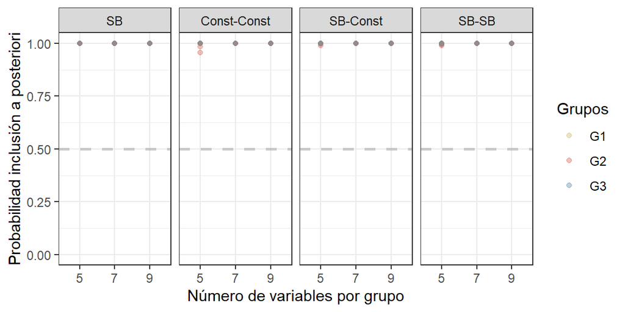

### Variables agrupadas

En general:

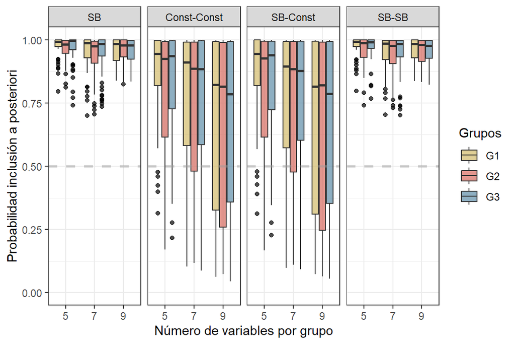

En función del número de variables:

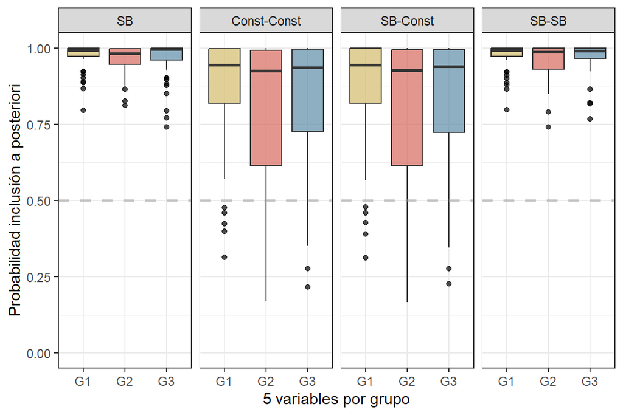

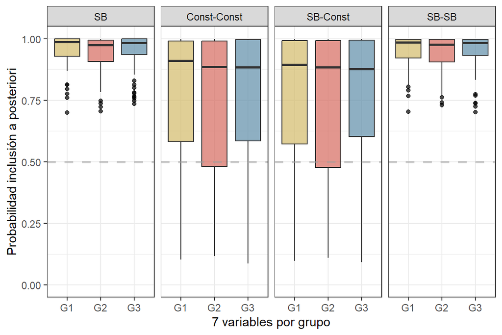

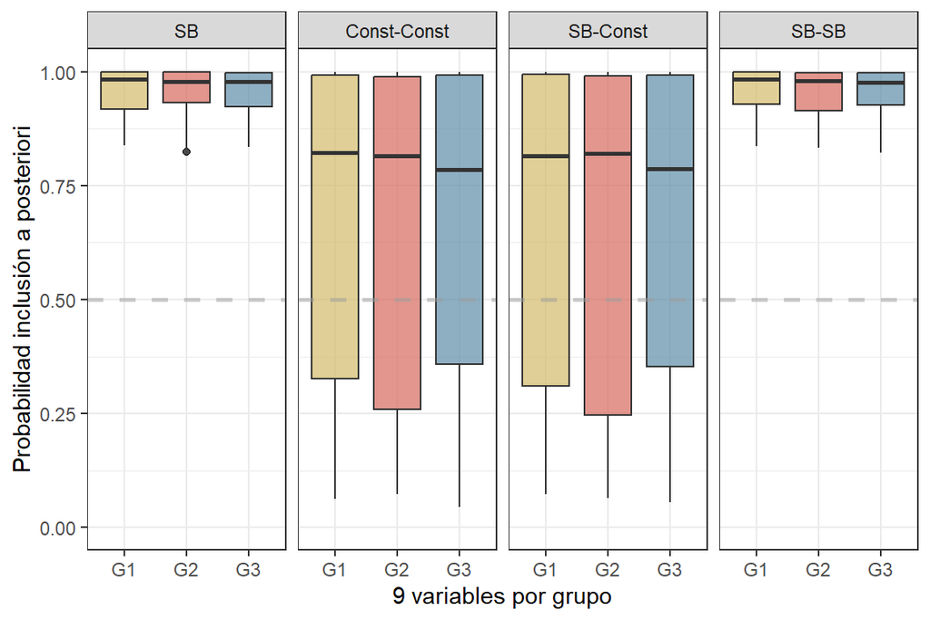

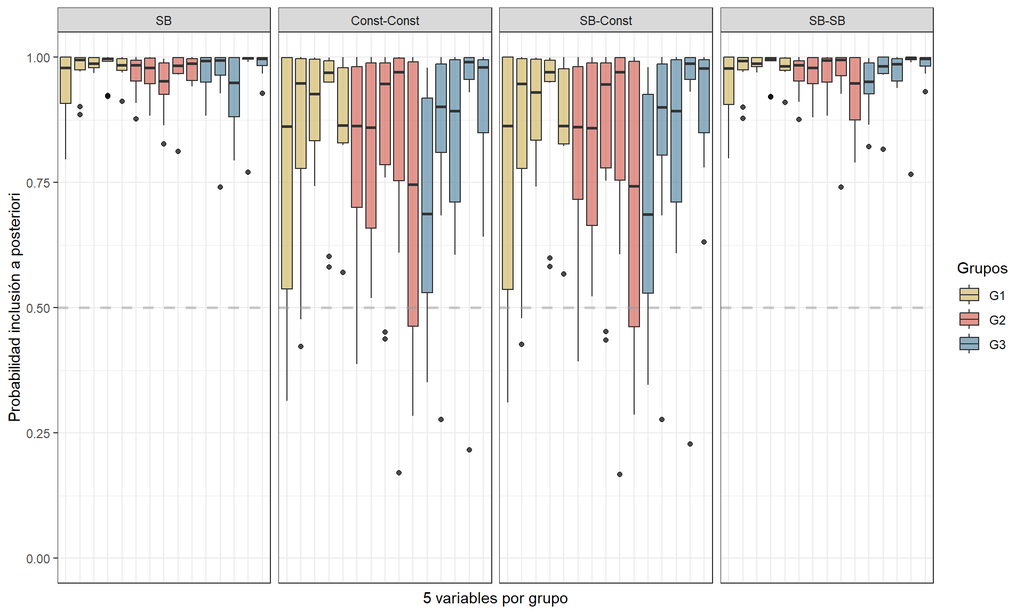

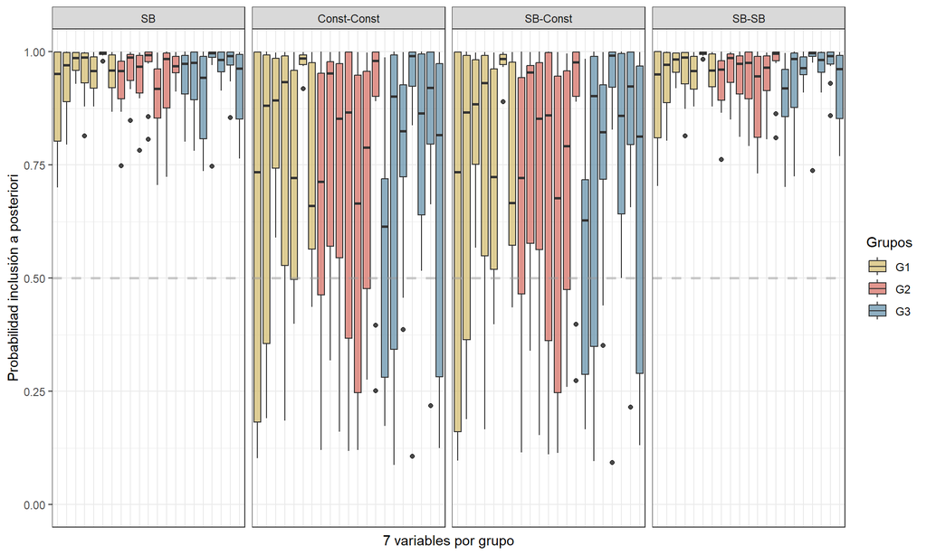

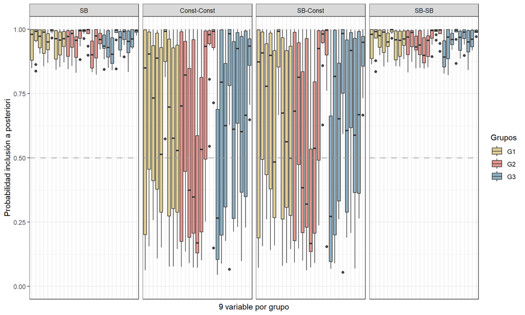

Porcentaje de variables agrupadas incorrectamente no seleccionados:

Porcentaje de variables agrupadas incorrectamente no seleccionadas para SB.

|  | G1 | G2 | G3 |
| --- | --- | --- | --- |
| Num vars = 5 | 0% | 0% | 0% |
| Num vars = 7 | 0% | 0% | 0% |
| Num vars = 9 | 0% | 0% | 0% |

Porcentaje de variables agrupadas incorrectamente no seleccionadas para Const-Const.

|  | G1 | G2 | G3 |
| --- | --- | --- | --- |
| Num vars = 5 | 10% | 14% | 10% |
| Num vars = 7 | 22.8571428571429% | 27.1428571428571% | 21.4285714285714% |
| Num vars = 9 | 34.4444444444444% | 37.7777777777778% | 33.3333333333333% |

Porcentaje de variables agrupadas incorrectamente no seleccionadas para SB-Const.

|  | G1 | G2 | G3 |
| --- | --- | --- | --- |
| Num vars = 5 | 10% | 14% | 10% |
| Num vars = 7 | 22.8571428571429% | 25.7142857142857% | 21.4285714285714% |
| Num vars = 9 | 36.6666666666667% | 38.8888888888889% | 33.3333333333333% |

Porcentaje de variables agrupadas incorrectamente no seleccionadas para SB-SB.

|  | G1 | G2 | G3 |
| --- | --- | --- | --- |
| Num vars = 5 | 0% | 0% | 0% |
| Num vars = 7 | 0% | 0% | 0% |
| Num vars = 9 | 0% | 0% | 0% |